# Evolution of pre-copulatory and post-copulatory strategies of inbreeding avoidance and associated polyandry

4 May 2017

# Abstract

Inbreeding depression is widely hypothesised to drive adaptive evolution of pre-copulatory and post-copulatory mechanisms of inbreeding avoidance, which in turn are hypothesised to affect evolution of polyandry (i.e., female multiple mating). However, surprisingly little theory or modelling critically examines selection for pre-copulatory or post-copulatory inbreeding avoidance, or both strategies, given evolutionary constraints and direct costs, or examines how evolution of inbreeding avoidance strategies might feed back to affect evolution of polyandry. Selection for post-copulatory inbreeding avoidance, but not for pre-copulatory inbreeding avoidance, requires polyandry, while interactions between pre-copulatory and post-copulatory inbreeding avoidance might cause functional redundancy (i.e., ‘degeneracy’) potentially generating complex evolutionary dynamics among inbreeding strategies and polyandry. We use individual-based modelling to quantify evolution of interacting pre-copulatory and post-copulatory inbreeding avoidance and associated polyandry given strong inbreeding depression and different evolutionary constraints and direct costs. We find that evolution of post-copulatory inbreeding avoidance increases selection for initially rare polyandry, and that selection for a costly inbreeding avoidance strategy was weak or negligible given a cost free alternative strategy. Further, fixed pre-copulatory inbreeding avoidance often completely precluded evolution of polyandry and hence post-copulatory inbreeding avoidance, but fixed post-copulatory inbreeding avoidance did not preclude evolution of pre-copulatory inbreeding avoidance. Evolution of inbreeding avoidance phenotypes and associated polyandry are therefore affected by evolutionary feedbacks and degeneracy. All else being equal, evolution of pre-copulatory inbreeding avoidance and resulting low polyandry is more likely when post-copulatory inbreeding avoidance is precluded or costly, and evolution of post-copulatory inbreeding avoidance greatly facilitates evolution of costly polyandry.

# Introduction

Inbreeding, defined as reproduction between relatives, often greatly reduces the fitness of resulting inbred offspring (termed “inbreeding depression”; Charlesworth and Charlesworth 1999; Keller and Waller 2002; Charlesworth and Willis 2009). Such strong inbreeding depression is widely hypothesised to drive evolution of inbreeding avoidance, which can be enacted through multiple interacting reproductive strategies (Parker 1979, 2006; Pusey and Wolf 1996; Szulkin et al. 2013).

From the perspective of a breeding female, inbreeding avoidance might be achieved by avoiding mating with related males (i.e., pre-copulatory inbreeding avoidance), or by biasing fertilisation towards unrelated males after mating has occurred (i.e., post-copulatory inbreeding avoidance). Evolution of such post-copulatory inbreeding avoidance is likely to be facilitated when females express some degree of polyandry, defined as mating with multiple males during a single reproductive bout (but see Dougherty et al. 2016). Such polyandry might itself be under selection and evolve if it allows females to mate with additional unrelated males following an initial mating with a relative. Polyandry can thereby facilitate pre-copulatory inbreeding avoidance even without any post-copulatory female choice or otherwise biased fertilisation among sperm provided by females’ mates (i.e., under conditions of a ‘fair raffle’). Overall, polyandry can therefore simultaneously allow females to mate with less closely related males and create the opportunity for further inbreeding avoidance enacted through active post-copulatory choice. Polyandry has consequently been widely hypothesised to allow females to avoid inbreeding and thereby increase offspring fitness (Zeh and Zeh 1997; Jennions and Petrie 2000; Tregenza and Wedell 2002). Resulting indirect selection on polyandry that stems from the increase in offspring fitness could explain evolution of polyandry in cases where multiple mating does not increase female reproductive success, or even reduces reproductive success and therefore imposes direct costs on polyandrous females. However, despite such widely-invoked hypotheses regarding the role of inbreeding depression in driving pre-copulatory and post-copulatory strategies and polyandry, there is surprisingly little theory or modelling that critically examines the conditions under which pre-copulatory or post-copulatory inbreeding avoidance, or both strategies, are predicted to evolve, or that examines how the evolution of such strategies of inbreeding avoidance might feed back to affect underlying evolution of polyandry.

Duthie et al. (2016) used a genetically-explicit individual-based model to examine the conditions under which polyandry is predicted to evolve due to selection stemming from pre-copulatory inbreeding avoidance in the absence of any post-copulatory inbreeding avoidance. Net selection for polyandry occurred only under highly restricted conditions, requiring that direct negative selection (i.e., ‘costs’) on polyandry was weak, that very few males were available for a female’s initial mate choice but many were available for additional mate choice(s), or that polyandry was conditionally expressed when a focal female was related to her initial mate (Duthie et al. 2016). Without these conditions, increasing polyandry tended to increase rather than decrease the overall degree of inbreeding that females experienced, and hence reduce offspring fitness. This occurred because, once pre-copulatory inbreeding avoidance evolved, polyandrous females had already chosen available unrelated males as their initial mates. Their additional mates, chosen from the remaining male population, were therefore increasingly likely to include relatives. Evolution of polyandry purely to facilitate pre-copulatory inbreeding avoidance, and hence the resulting degree of inbreeding avoidance, was consequently restricted (Duthie et al. 2016).

However, if post-copulatory inbreeding avoidance could also evolve, polyandrous females would have the opportunity to bias paternity towards unrelated males within their set of chosen mates. Evolution of post-copulatory inbreeding avoidance might consequently reduce the cost of polyandry stemming from the accumulation of related mates across multiple matings, potentially facilitating evolution of polyandry to avoid inbreeding under broader conditions, and driving further evolution of pre-copulatory or post-copulatory mate choice strategies. Subsequently, if polyandry and pre-copulatory and post-copulatory inbreeding avoidance can all evolve, the long-term dynamics of these three reproductive strategies become difficult to predict. Strong inbreeding depression might drive initial evolution of both pre-copulatory and post-copulatory inbreeding avoidance and associated polyandry. However, the co-occurrence of pre-copulatory and post-copulatory inbreeding avoidance might engender some degree of ‘degeneracy’, defined as a phenomenon by which different elements of a system result in identical outputs (Edelman and Gally 2001). Consequently, if evolution of polyandry and post-copulatory inbreeding avoidance renders pre-copulatory inbreeding avoidance functionally redundant, or vice versa, then only one inbreeding avoidance strategy might be maintained in the long-term.

The few previous models that considered the evolution of inbreeding avoidance through mate choice (as opposed to dispersal) have implicitly or explicitly considered the fate of a rare allele underlying pre-copulatory inbreeding avoidance in a population initially fixed for random mating (e.g., Parker 1979, 2006; Duthie et al. 2016; Duthie and Reid 2016). Such models are useful for isolating the invasion fitness of this single strategy. However, when both pre-copulatory and post-copulatory strategies can affect the realised degree of inbreeding, it cannot be assumed that both strategies will simultaneously invade a randomly mating population, nor that the invasion fitness of one strategy will be independent of the pre-existence or invasion fitness of the other strategy. For example, if pre-adaptation or a selective sweep results in fixation of alleles underlying pre-copulatory inbreeding avoidance, then new alleles underlying polyandry and post-copulatory inbreeding avoidance might be unlikely to invade a population because the phenotypic effect of such alleles on the overall degree of inbreeding, and resulting indirect selection, could be negligible. Conversely, fixation of alleles underlying polyandry and post-copulatory inbreeding avoidance might reduce or eliminate positive selection on alleles underlying pre-copulatory inbreeding avoidance and hence impede adaptive evolution of mate choice. New theory, guided by modelling that evaluates invasion dynamics of alleles underlying multiple interacting and potentially functionally redundant (i.e., `degenerate’) traits, is therefore needed.

Ultimately, the absolute and relative frequencies of alleles underlying pre-copulatory and post-copulatory inbreeding avoidance and polyandry will depend not only on the magnitudes of positive indirect selection stemming from reduced inbreeding depression in females’ offspring, but also on the magnitudes of direct negative selection on resulting phenotypes (i.e., the direct fitness costs of expressing each reproductive strategy). Polyandrous females can pay costs of mate searching or mating, for example, because these activities increase predation risk (e.g., Rowe 1988; Ronkainen and Ylonen 1994; Koga et al. 1998). Females that express pre-copulatory choice and consequent reluctance to mate with relatives might pay costs of increased risk of complete mating failure or harm caused by sexual conflict (Rowe et al. 1994; Kokko and Mappes 2013). Females that express post-copulatory choice might pay initial energetic costs associated with developing the physiological or biochemical mechanisms needed to store sperm and successfully bias fertilisation (e.g., Gasparini and Pilastro 2011; Tuni et al. 2013; Fitzpatrick and Evans 2014). If the relative costs of pre-copulatory and post-copulatory inbreeding avoidance differ, then alleles underlying the less costly strategy might become fixed over generations, while alleles underlying the more costly strategy might become extinct, especially if their effects are made redundant by evolution of the less costly strategy. Evolutionary dynamics will therefore depend on the benefits of each strategy, which might also differ and vary in relation to the evolution of the other strategy. Dynamic models that track the frequencies of alleles underlying multiple reproductive strategies that might influence each others evolution across generations, and that are enacted among relatives that themselves result from reproductive strategies and inbreeding depression expressed in previous generations, are consequently useful to understand and predict evolutionary outcomes.

We use individual-based modelling to address three key questions regarding evolution of pre-copulatory and post-copulatory inbreeding avoidance and associated polyandry given opportunity for inbreeding and strong inbreeding depression. First, does evolution of post-copulatory inbreeding avoidance alongside pre-copulatory inbreeding avoidance facilitate evolution of polyandry that is otherwise severely constrained by increasing relatedness of polyandrous females’ additional mates? Second, how do costs associated with polyandry and pre-copulatory and post-copulatory inbreeding avoidance affect evolutionary outcomes and, in particular, the long-term persistence of these reproductive strategies given cost asymmetry? Third, how is selection for initially rare pre-copulatory or post-copulatory inbreeding avoidance affected if the other strategy of inbreeding avoidance is already fixed? By addressing these questions, we illustrate how the simultaneous evolution of multiple interacting degenerate reproductive strategies can generate diverse evolutionary outcomes.

# Model

We model evolution of polyandry, and of pre-copulatory and post-copulatory inbreeding avoidance strategies (hereafter simply ‘inbreeding strategies’ because the model did not preclude evolution of inbreeding preference), in a small focal population of females and males by tracking the dynamics of alleles underlying reproductive strategies expressed by females. We thereby track evolutionary dynamics given internally consistent patterns of relatedness caused by non-random mating and allowing for effects of mutation, gene flow, drift, and selection.

All individuals have 10 physically unlinked diploid loci, and therefore 20 alleles, underlying each of three reproductive strategy traits (i.e., 30 diploid loci in total): tendency for polyandry ($P_{a}$, i.e., ‘polyandry’ alleles), pre-copulatory inbreeding strategy ($M_{a}$, i.e., ‘mating’ alleles), and post-copulatory inbreeding strategy ($F_{a}$, i.e., ‘fertilisation’ alleles). All alleles can take the value of any real number (i.e., a continuum-of-alleles model; Kimura 1965; Lande 1976; Reeve 2000; Bocedi and Reid 2014) and combine additively to determine genotypes ($P_{g}$, $M_{g}$, and $F_{g}$) and resulting phenotypes ($P_{p}$, $M_{p}$, and $F_{p}$) for tendency for polyandry, pre-copulatory inbreeding strategy, and post-copulatory inbreeding strategy, respectively. Each individual’s genotypic values $P_{g}$, $M_{g}$, and $F_{g}$ equal the sum of its 20 alleles for each trait. Each individual’s phenotypic values for pre-copulatory and post-copulatory inbreeding strategy equal their respective genotypic values ($M_{p} = M_{g}$ and $F_{p} = F_{g}$), where negative and positive values cause inbreeding avoidance and preference, respectively (see details of mating and fertilisation strategies below). In contrast, phenotypic values for tendency for polyandry equal genotypic values ($P_{p} = P_{g}$) only if $P_{g} \geq 0$, while $P_{p} = 0$ if $P_{g} < 0$ because females cannot choose a negative number of mates. Polyandry is therefore modelled as a threshold trait (Roff 1996, 1998; Lynch and Walsh 1998; Duthie et al. 2016) that is influenced by continuous genetic variation but only expressed when $P_{g} > 0$. A negative $P_{g}$ value therefore generates a female that is phenotypically monandrous, while a positive $P_{g}$ value generates a female that can express some degree of polyandry (see details below).

In overview, each generation proceeds with females paying costs associated with their reproductive strategy traits, and expressing polyandry, mating, and fertilisation. Offspring inherit a randomly sampled allele from each parent at each locus. Alleles can then mutate and offspring express inbreeding depression in viability. Immigrants arrive in the population and density regulation limits population growth. We record the population pedigree and directly calculate the coefficient of kinship ($k$) between all potential mates in each generation (defined as the probability that two homologous alleles will be identical-by-descent), allowing individual pre-copulatory and post-copulatory inbreeding strategies to be enacted. Key individual traits, parameter values, and variables are described in Table 1.

## Costs

Phenotypic values of the three reproductive strategy traits each have costs that are assumed to combine independently to increase the probability that a focal female will die before mating (see Discussion for consideration of other costs). The probabilities of pre-mating mortality due to the costs of polyandry ($c_{P}$), pre-copulatory inbreeding strategy ($c_{M}$), and post-copulatory inbreeding strategy ($c_{F}$) are $P_{p} \times c_{P}$, $|M_{p}| \times c_{M}$, and $|F_{p}| \times c_{F}$, respectively. Here $|M_{p}|$ and $|F_{p}|$ are the absolute values of $M_{p}$ and $F_{p}$, respectively. Absolute values are used for applying costs to inbreeding avoidance strategies because both negative and positive $M_{p}$ and $F_{p}$ values could potentially arise and affect the degree of inbreeding, representing inbreeding avoidance and inbreeding preference, respectively. In contrast, $P_{p}$ cannot be negative. Overall, because generations are non-overlapping, a female’s probability of total reproductive failure increases linearly with the phenotypic value of each trait.

## Mating and pre-copulatory inbreeding avoidance

After costs are realised, each remaining female chooses $N_{males}$ males to mate with, where $N_{males}$ is calculated by sampling from a Poisson distribution such that $N_{males} = Poisson(P_{p}) + 1$. This ensures that all surviving females choose at least one mate and generates each female’s realised degree of polyandry with some stochastic variation around the expected mean $N_{males}$ of $P_{p}+1$.

All males in the population are assumed to be available for any female to choose. We therefore assume that there is no opportunity cost of male mating, so mating with one female does not reduce a male’s availability to mate with any other female. Females mate with $N_{males}$ without replacement, meaning that $N_{males}$ models a female’s total number of different mates rather than solely her total number of matings.

Most often, $N_{males}$ will be smaller than the total number of available males (Duthie et al. 2016). Each female then chooses her $N_{males}$ mates based on her pre-copulatory inbreeding avoidance phenotype ($M_{p}$). Negative or positive $M_{p}$ values cause a female to avoid or prefer mating with kin, respectively, whereas $M_{p}=0$ cause females to mate randomly with respect to kinship.

Each male’s value with respect to a female $i$ is then divided by the sum of all $Q^{m}_{ij}$ values across all males with respect to that female, thereby assigning each male a relative perceived quality $q^{m}_{ij}$, which is constrained to values between zero and one. The value of $q^{m}_{ij}$ then defines the probability that female $i$ mates with male $j$. Mating is therefore stochastic, and females do not always mate with the male of the highest $q^{m}_{ij}$. For polyandrous females that choose multiple mates (i.e., $N_{mates}>1$), mates are chosen iteratively such that $Q^{m}_{ij}$ and $q^{m}_{ij}$ are re-calculated for each additional mate choice, and with $Q^{m}_{ij}$ and therefore $q^{m}_{ij}$ values of already chosen males set to zero to ensure mate sampling without replacement. In the unlikely event that a female’s $N_{males}$ exceeds the total number of available males, then she simply mates with all males.

## Fertilisation and post-copulatory inbreeding avoidance

Following mating, fertilisation occurs such that each of a female’s $n$ offspring is independently assigned a sire (with replacement) from the $N_{males}$ with which the female mated. Sire identity depends on female’s kinship with each mate ($k_{ij}$) and her post-copulatory inbreeding strategy phenotype ($F_{p}$). Negative and positive values of $F_{p}$ correspond to post-copulatory inbreeding avoidance or preference, respectively, whereas $F_{p}=0$ causes random fertilisation with respect to kinship.

The probability that an offspring of female $i$ is sired by any one of $i$’s mates $j$ is calculated by assigning a perceived fertilisation quality to each $j$ with respect to $i$, $Q^{f}_{ij}$. Perceived fertilisation quality $Q^{f}_{ij}$ is calculated in the same way as perceived mate quality $Q^{m}_{ij}$, such that if female $i$ has a strategy of post-copulatory inbreeding avoidance ($F_{p}<0$), then the perceived quality of male $j$ is $Q^{f}_{ij} = (-F_{p} \times k_{ij} + 1)^{-1}$. If the female has strategy of post-copulatory inbreeding preference ($F_{p}>0$), then the perceived quality of male $j$ is $Q^{f}_{ij} = F_{p} \times k_{ij} + 1$. A relative quality ($q^{f}_{ij}$) is then calculated for each male by dividing his $Q^{f}_{ij}$ by the sum of the $Q^{f}_{ij}$ values across all of a female’s mates. These $q^{f}_{ij}$ values, which lie between zero and one, define the probability of paternity. Females produce $n$ offspring, so a female $i$ samples from her mates $n$ times independently and with replacement with a probability of $q^{f}_{ij}$ for each male $j$ to determine the realised distribution of sires. Offspring have equal probability of being female or male.

## Mutation

Offsprings’ alleles mutate with independent probabilities $\mu=0.001$. When a mutation occurs, a mutation effect is sampled from a normal distribution with a mean of zero and a standard deviation of $\mu_{SD}$ and added to the original allele value (Kimura 1965; Lande 1976; Bocedi and Reid 2014; Duthie et al. 2016). The value of $\mu_{SD}$ is set to $\sqrt{1/20}$ because 20 independent alleles underlie each trait’s genotypic value.

## Inbreeding depression

The viability of a female $i$’s offspring ($\Psi_{\textrm{off}}$) decreases as a log-linear function of her kinship with the sire $j$ of the offspring ($k_{ij}$) and inbreeding depression slope $\beta$,
$$\begin{equation}
\Psi_{\textrm{off}} = e^{-\beta k_{ij}}
\end{equation}$$

Here, $\beta$ models the number of haploid lethal equivalents that exist as deleterious recessive alleles in the gametes of $i$ and $j$, and which might be homozygous in offspring and reduce viability. Equation 1 assumes independent allelic effects, generating multiplicative effects on offspring viability (Morton et al. 1956; Mills and Smouse 1994). We model inbreeding depression as having an absolute rather than relative effect on offspring viability (i.e., hard rather than soft selection), so that the effect of $\beta$ is consistent across generations and different parameter combinations. We assume that inbreeding always decreases offspring viability (i.e., $\beta > 0$, giving inbreeding depression but no outbreeding depression). Therefore, because $0 \leq k_{ij} \leq 1$, $-\beta \times k_{ij} \leq 0$. Values of $\Psi_{\textrm{off}}$ must therefore be between zero (if $-\beta \times k_{ij}$ is very negative) and one (if $-\beta \times k_{ij} = 0$). We therefore define $\Psi_{\textrm{off}}$ as the probability that an offspring is viable, and sample its realised viability (versus mortality) using a Bernoulli trial. Given our current objectives, we simulate evolution under conditions where inbreeding avoidance is adaptive due to strong inbreeding depression, and not evolution where inbreeding preference is adaptive due to weak or zero inbreeding depression (Parker 1979; Kokko and Ots 2006; Duthie and Reid 2016), or given outbreeding depression (Bateson 1983; Greeff et al. 2009). However, as described above, positive $M_{p}$ and $F_{p}$ values resulting in inbreeding preference are not precluded from evolving, and could potentially arise due to mutation or drift.

## Immigration

After offspring mortality, $\rho$ adult immigrants are added to the focal population. The kinship between an immigrant and all other individuals always equals zero ($k_{ij}=0$). Immigration therefore prevents the mean kinship within the population from asymptoting to one over generations. To ensure that immigrants do not directly affect genotypic or phenotypic values of tendency for polyandry or pre-copulatory or post-copulatory inbreeding avoidance, immigrants are always male. Consequently, they can be chosen as females’ mates based on their values of $k_{ij}=0$ but do not actively affect reproductive decisions through the expression of $P_{p}$, $M_{p}$, or $F_{p}$. Further, immigrants’ $P_{a}$, $M_{a}$, and $F_{a}$ allele values are randomly sampled from normal distributions with means and standard deviations equal to those in the focal population at the time of immigration, meaning that they do not directly cause any change in the distribution of allele values. We thereby effectively assume that the focal population receives immigrants from other nearby populations that are subject to the same selection on $P_{p}$, $M_{p}$, and $F_{p}$ (Duthie et al. 2016; Duthie and Reid 2016).

## Density regulation

To avoid unrestricted population growth, we set separate carrying capacities for the total numbers of females ($K_{f}$) and males ($K_{m}$) in the focal population following immigration (Guillaume and Perrin 2009; Duthie et al. 2016). If at the end of a generation the number of females or males exceeds $K_{f}$ or $K_{m}$ respectively, then individuals are randomly removed until each sex is at its carrying capacity. Such removal can be interpreted as some combination of dispersal and mortality. The remaining females and males form the next generation of potentially breeding adults.

## Simulations and analysis

To address whether or not evolution of post-copulatory inbreeding avoidance alongside pre-copulatory inbreeding avoidance can facilitate evolution of polyandry, we compare simulations in which polyandry and pre-copulatory and post-copulatory inbreeding avoidance can all evolve with otherwise identical simulations in which post-copulatory inbreeding avoidance cannot evolve. To achieve this, we sever the connection from $F_{a}$ to $F_{p}$ such that all $F_{g}$ genotypes cause random fertilisation with respect to kinship, so $F_{a}$ alleles have no phenotypic effect. Simulations were repeated across four different costs of polyandry ($c_{P} = \{0, 0.0025, 0.005, 0.01\}$).

To address how asymmetric costs associated with pre-copulatory and post-copulatory inbreeding avoidance and polyandry affect the long-term persistence of reproductive strategies, we quantify the change in $M_{a}$ and $F_{a}$ over generations in simulations where pre-copulatory inbreeding strategy was cost free ($c_{M}=0$) but post-copulatory inbreeding strategy was moderately costly ($c_{F}=0.02$), and vice versa. We compare evolutionary trajectories with those of a costly strategy in the absence of evolution of an alternative strategy (e.g., evolution of pre-copulatory inbreeding strategy when post-copulatory inbreeding strategy phenotype is fixed at zero, $F_{p}=0$). Previous modelling using similar genetic architecture suggests that a cost of $0.02$ imposes strong but not overwhelming direct negative selection on polyandry (Duthie et al. 2016). This value is therefore appropriate to illustrate the different evolutionary consequences that could result from asymmetrical costs.

To address how selection on an initially rare strategy of pre-copulatory or post-copulatory inbreeding avoidance, and resulting evolution, is affected by the other strategy of inbreeding avoidance already being fixed in the population, we first used exploratory simulations to quantify evolution of pre-copulatory inbreeding strategy, and of post-copulatory inbreeding strategy and associated polyandry, in isolation. Then, to test whether pre-copulatory inbreeding avoidance would evolve when adaptive polyandry and post-copulatory inbreeding avoidance were fixed, we initiated $M_{a}$ allele values at zero, but fixed $F_{a}$ allele values at $-10$ and $P_{a}$ allele values at $1$ (i.e., $F_{p}$ and $P_{p}$ were expressed did not evolve further). Similarly, to test whether post-copulatory inbreeding avoidance would evolve when pre-copulatory inbreeding avoidance was already fixed, we initiated $F_{a}$ and $P_{a}$ allele values at zero but fixed $M_{a}$ allele values at $-10$. Consequently, because females have 10 diploid loci, when $M_{a}$ or $F_{a}$ alleles were fixed at $-10$, outbred females were $51$ times less likely to choose a full brother and $13.5$ times times less likely to choose a first cousin than a non-relative in pre-copulatory and post-copulatory choice, respectively.

In all simulations, we recorded mean values of $P_{a}$, $M_{a}$, and $F_{a}$ in each generation and present these values over generations to infer selection on phenotypes ($P_{p}$, $M_{p}$, and $F_{p}$). Each combination of parameter values simulated was replicated $40$ times, and grand mean values and standard errors of means are calculated in each generation across replicates. These analyses allowed us to infer how allele values changed over generations in response to costs, but also in response to the changing values of other alleles and therefore potential evolutionary feedbacks among reproductive strategies. For all replicates, we set the maximum number of generations to 40000, which exploratory simulations and previous modelling (Duthie et al. 2016) showed to be sufficient for inferring long-term dynamics of mean allele values and therefore selection on phenotypes. For all replicates, we set $\rho=5$ immigrants, which produced a range of kin and non-kin in each generation allowing females to express inbreeding strategies, and $n=8$ offspring, which was sufficient to keep populations consistently at carrying capacities and avoid population extinction. Values of $K_{f}$ and $K_{m}$ were both set to 100 because previous modelling showed that populations of this size are small enough that mate encounters between kin occur with sufficient frequency for selection on inbreeding strategy, but not so small that selection is typically overwhelmed by drift (Duthie and Reid 2016).

# Results

## Does evolution of post-copulatory inbreeding avoidance facilitate evolution of costly polyandry?

When post-copulatory inbreeding avoidance alleles ($F_{a}$) had no effect (i.e., $F_{g}$ values were fixed to zero), meaning that $F_{p}$ could not evolve, $P_{a}$ alleles underlying polyandry always decreased to negative values over generations (red lines, Figure 1A,C,E,G). This shows that despite strong inbreeding depression in offspring viability, there is selection against unconditional polyandry even given zero direct cost ($c_{P}=0$; Figure 1A). This is because $M_{a}$ values became negative over generations, meaning that females typically avoided inbreeding through their initial mating (blue lines, Figure 1A,C,E,G). Polyandrous females that subsequently sampled more males from the available population were consequently more likely to mate with some relatives and hence produce some inbred offspring with low viability (Duthie et al. 2016).

Strong post-copulatory inbreeding avoidance, manifested as very negative $F_{a}$ values, consistently evolved in all simulations where such evolution was allowed (black lines, Figure 1B,D,F,H). Evolution of post-copulatory inbreeding avoidance occurred even when $P_{a}$ values were expected to be slightly negative, and hence when there was selection against alleles underlying polyandry (Figure 1F,H). This reflects the threshold nature of phenotypic expression of polygenic polyandry, wherein random sampling of alleles means that polyandry is expressed by some females (i.e., $P_{g}>0$) even when mean $P_{a}$ values are negative (Figure 2). This means that, even in populations where female reproductive strategy evolves toward monandry, there is still commonly some opportunity for expression of post-copulatory inbreeding avoidance and associated selection that drives evolution of post-copulatory inbreeding avoidance.

Strong pre-copulatory inbreeding avoidance evolved (i.e., $M_{a}<0$) in all simulations, irrespective of $c_{P}$ and irrespective of whether post-copulatory inbreeding avoidance was allowed to evolve or hence whether polyandry evolved (Figure 1). This might be expected given strong inbreeding depression in offspring viability, which imposes selection against inbreeding.

## How do cost asymmetries affect long-term persistence of reproductive strategies?

When post-copulatory inbreeding avoidance allele values ($F_{a}$) were fixed to zero, pre-copulatory inbreeding avoidance evolved even when costly (Figure 3A). Likewise, when pre-copulatory inbreeding avoidance allele values ($M_{a}$) were fixed to zero, costly post-copulatory inbreeding avoidance evolved (Figure 3C). Females therefore evolved to avoid inbreeding, and thereby avoid the indirect cost of producing inbred offspring, through whichever route was available.

However, when both pre-copulatory and post-copulatory inbreeding avoidance could evolve, their relative evolutionary dynamics depended on their relative costs. When pre-copulatory but not post-copulatory inbreeding avoidance was costly ($c_{M}=0.02$ and $c_{F}=0$), pre-copulatory inbreeding avoidance initially evolved (i.e., $M_{a} < 0$) but then evolved back towards random mating (i.e., $M_{a} \approx 0$) following increasing evolution of post-copulatory inbreeding avoidance and polyandry (Figure 3B). Similarly, when post-copulatory but not pre-copulatory inbreeding avoidance was costly ($c_{F}=0.02$ and $c_{M}=0$), post-copulatory inbreeding avoidance initially evolved (i.e., $F_{a} < 0$) before evolving back to random fertilisation (i.e., $F_{a} \approx 0$) after ca $20000$ generations (Figure 3D).

When pre-copulatory inbreeding avoidance was costly, allowing evolution of cost free post-copulatory inbreeding avoidance greatly facilitated evolution of polyandry (Figure 3A versus 3B). However when post-copulatory inbreeding avoidance was costly, allowing evolution of cost free pre-copulatory inbreeding avoidance caused $P_{a}$ alleles to decrease to very negative values, reducing expression of polyandry (Figure 3C versus 3D; polyandry was cost free in all these simulations). Results for all possible cost combinations of $0$ and $0.02$ are provided in Supporting Information (Figure S9).

## How does fixation of pre-copulatory or post-copulatory inbreeding avoidance affect evolution?

When polyandry alleles ($P_{a}$) were fixed to be positive so that all females were expected to mate multiply and post-copulatory inbreeding allele ($F_{a}$) values were fixed for adaptive inbreeding avoidance, pre-copulatory inbreeding avoidance evolved (i.e., $M_{a}$ values became increasingly negative; Figure 4A). Such evolution still occurred, but to a much smaller degree, when pre-copulatory inbreeding avoidance was costly (Figure 4B). However, after $40000$ generations, $M_{a}$ values were less negative when post-copulatory inbreeding avoidance and polyandry were fixed at non-zero values than when they also evolved from initial values of zero ($-15.45$ vs. $-17.62$; compare the blue lines in Figures 4A versus Figure 1B). This shows that fixation of post-copulatory inbreeding avoidance weakens selection for pre-copulatory inbreeding avoidance.

Conversely, when pre-copulatory inbreeding allele ($M_{a}$) values were fixed for adaptive inbreeding avoidance, mean $F_{a}$ allele values did not consistently become negative over generations (Figure 4C,D). Fixation of pre-copulatory inbreeding avoidance therefore prevented evolution of post-copulatory inbreeding avoidance. In this case, mean $P_{a}$ allele values consistently decreased over generations, reflecting selection against polyandry regardless of whether or not post-copulatory inbreeding avoidance was costly (Figure 4C,D). Consequently, when $c_{F}=0$, $F_{a}$ allele values had no effect because females were almost exclusively monandrous, resulting in high drift of $F_{a}$ values (resulting in variation among replicates illustrated by the wide standard errors in Figure 4C). However, when $c_{F}=0.02$, $F_{a}$ values remained near zero to minimise direct costs. This lack of selection for post-copulatory inbreeding avoidance was driven by a lack of polyandry, and therefore an inability of females to bias fertilisation among multiple mates. When pre-copulatory inbreeding avoidance and polyandry were both fixed ($M_{a}=-10$ and $P_{a}=1$), $F_{a}$ allele values evolved to similarly negative means as $M_{a}$ allele values in Figure 4A,B (see Supporting Information Figure S10).

# Discussion

Evolution of different reproductive strategies cannot be presumed to occur in isolation from each other in real-world populations. Rather, such evolution is likely to involve multiple interacting phenotypes resulting in the potential for feedback and degeneracy (i.e., functional redundancy) among phenotypes under selection. For example, strong inbreeding depression in offspring fitness is widely hypothesised to drive selection for inbreeding avoidance, which could consequently drive selection for polyandry (e.g., Zeh and Zeh 1997; Jennions and Petrie 2000; Tregenza and Wedell 2002). Inbreeding avoidance could be manifested through both pre-copulatory and post-copulatory mechanisms, meaning that simultaneous evolution of each phenotype might be defined by degeneracy in addition to trait-specific costs. We used individual-based modelling to highlight fundamental but theoretically under-developed relationships between evolution of polyandry and pre-copulatory versus post-copulatory inbreeding strategy given (1) hard constraints on evolution of post-copulatory inbreeding strategy, (2) asymmetric costs of pre-copulatory and post-copulatory inbreeding strategy, and (3) evolution of one inbreeding strategy phenotype given the pre-existence of the other. We present our model and simulation results as a tool for thinking more clearly about the dynamics of simultaneously evolving reproductive strategies, not for making accurate quantitative predictions for any specific system. While the logic of our model can be usefully applied to constructing hypotheses within and across empirical systems, accurate quantitative prediction would require additional detail and the incorporation of empirical data for model parameterisation.

## Evolution of polyandry

The opportunity to adjust inbreeding has been widely suggested to be a driver of adaptive evolution of polyandry (Tregenza and Wedell 2002; Foerster et al. 2003; Akçay and Roughgarden 2007; Varian-Ramos and Webster 2012; Kingma et al. 2013; Lehtonen and Kokko 2015; Reid et al. 2015a). We found that when post-copulatory inbreeding avoidance could evolve, selection for and resulting evolution of polyandry was greatly strengthened (Figure 1). The proposition that polyandry might facilitate cryptic female choice among males of varying compatibility is not new (e.g., Zeh and Zeh 1997), but our model clarifies this verbal hypothesis and therefore has widespread implications for future studies of evolution of polyandry.

We predict evolution of polyandry in populations where inbreeding depression is severe and inbreeding avoidance through post-copulatory mechanisms can also evolve, especially if pre-copulatory inbreeding avoidance is costly (Figure 1). Post-copulatory mechanisms of inbreeding avoidance have been observed under these conditions in experimental systems across diverse taxa (e.g., Pizzari et al. 2004; Firman and Simmons 2008, 2015; Bretman et al. 2009; Gasparini and Pilastro 2011; Tuni et al. 2013). Recent studies have shown how females can successfully bias fertilisation after mating has occurred. For example, when female guppies (*Poecilia reticulata*) were artificially inseminated with equal quantities of sperm from full-siblings and unrelated males, more eggs were fertilised by unrelated males because the velocities of full siblings’ sperm were reduced by females’ ovarian fluids (Gasparini and Pilastro 2011). In black field crickets (*Teleogryllus commodus*), females attempt to remove the spermatophores of unwanted males after copulation, and are capable of controlling sperm transfer to spermatheca after copulation occurs (Bussiére et al. 2006; Tuni et al. 2013).

## Interaction of polyandry and inbreeding avoidance strategies

Evolution of both pre-copulatory and post-copulatory inbreeding avoidance occurred in our model, but were affected by the evolution of polyandry and the existence of asymmetric costs. One cost free strategy of inbreeding avoidance precluded another more costly strategy from persisting in a focal population (Figure 3). Consequently, long-term persistence of both pre-copulatory and post-copulatory inbreeding avoidance might not be expected in populations given sufficient cost asymmetry. Since direct costs strongly affected the evolution of the focal phenotype(s), quantifying costs is necessary for predicting evolution of inbreeding strategies.

Quantifying direct costs of phenotypes associated with polyandry and mate choice is empirically challenging (Pomiankowski 1987; Kokko et al. 2003). Pomiankowski (1987) categorised four types of costs that are relevant to mate choice, which are also relevant for polyandry, and include costs of elevated risks of predation or disease transmission, and costs incurred through time or energy expenditure. Consequently, we interpreted a cost of polyandy as an elevated risk of predation as might be incurred while searching for or courting mates (e.g., Rowe 1988; Rowe et al. 1994), a cost of pre-copulatory inbreeding strategy as a loss of time (i.e., risk of not finding a mate in time due to choosiness; e.g., Kokko and Mappes 2013), and a cost of post-copulatory inbreeding strategy as an up-front depletion of energy, all manifested as an increased probability of total reproductive failure. While these costs reflect empirical observations in some populations and are therefore biologically realistic, other types of costs have also been observed and could be considered in future models tailored to specific systems. For example, highly polyandrous females might experience increased risk of disease transmission (Roberts et al. 2015). Such a cost would more realistically apply to a female’s realised number of mates rather than her tendency for polyandry. Polyandrous females might also risk harm caused by sexual conflict over multiple mating (e.g., Arnqvist and Rowe 2005; Parker 2006). We assumed that males were passive in mating encounters with females, but inbreeding theory predicts that males should be more tolerant of inbreeding than females, leading to sexual conflict over inbreeding (Parker 1979, 2006; Kokko and Ots 2006; Duthie and Reid 2015). Future models could formally consider sexual conflict over both polyandry and inbreeding. Overall, such different types of costs might affect selection both directly and indirectly through interactions between reproductive strategies, thereby affecting evolution of entire reproductive systems. Evolution of reproductive strategies therefore needs to be considered in the broader context of potentially interacting and phenotypes and their costs.

## General predictions concerning inbreeding avoidance and polyandry

Post-copulatory inbreeding avoidance cannot be effectively realised if females are not polyandrous in any form, and is likely to be most effective for highly polyandrous females that can choose amongst sperm contributed by multiple mates and therefore bias fertilisation accordingly. In contrast, pre-copulatory inbreeding avoidance mechanisms are most critical for females that mate only once and therefore have no post-copulatory opportunity to avoiding inbreeding. This theory is borne out in our simulation results, as selection for, and consequent evolution of, post-copulatory inbreeding avoidance was negligible in populations where polyandry did not evolve, resulting in high drift of allele values over generations due to the inability of females to express post-copulatory choice (e.g., Figure 4C,D). Evolution of pre-copulatory inbreeding avoidance was also typically slightly stronger when polyandry did not evolve (e.g., Figure 3A vs 3B; see also Supporting Information Figure S9). In addition to initial polyandry causing evolution of post-copulatory inbreeding avoidance, polyandry might also covary positively with post-copulatory inbreeding avoidance due to the feed back effect that post-copulatory inbreeding avoidance has on facilitating evolution of polyandry itself, as observed in our model (Figure 1). It would therefore be interesting to test the hypothesis that, across taxa, the occurrence of post-copulatory inbreeding avoidance covaries positively, and the occurrence of pre-copulatory inbreeding avoidance covaries negatively, with the degree of polyandry. To test this hypothesis, more work is needed to quantify the degree to which females of different species engage in polyandry and the degree to which females express both pre-copulatory and post-copulatory inbreeding avoidance.

Degeneracy occurs at nearly all biological scales (Edelman and Gally 2001), including complex systems affecting organismal development (e.g., Nowak et al. 1997), adaptation (Whitacre and Bender 2010; Whitacre 2010), and cognition (Price and Friston 2002; Park and Friston 2013), as well as population (Atamas and Bell 2009), community (Suraci et al. 2017), and ecosystem (e.g., Levin and Lubchenco 2008) dynamics. In our model, degeneracy occurred through overlaps in how different reproductive strategies caused adaptive inbreeding avoidance. In general, degeneracy might increase biological robustness by fine-tuning degenerate phenotypes to different local environments (Gardner and Kalinka 2006; Whitacre 2010). For example, degeneracy might ensure successful inbreeding avoidance through either pre-copulatory or post-copulatory mechanisms when avoidance through the other mechanism is ineffective (e.g., due to sexual conflict affecting mate choice or injury affecting fertilisation). However, evolution of one inbreeding avoidance mechanism might also weaken selection on the other by modifying the latter’s impact on total realised inbreeding avoidance (*sensu* evolution of genetic redundancy; see Nowak et al. 1997). The relevance of degeneracy with respect to such reproductive strategies therefore requires further theoretical development, which could result in new empirical predictions and conceptual synthesis across biological scales.

## Table 1

Individual traits (A), model parameter values (B), and model variables (C) for an individual based model of the evolution of polyandry, pre-copulatory inbreeding strategy, and post-copulatory inbreeding strategy.

| **A** | **Trait** | **Allele** | **Genotype** | **Phenotype** |
| --- | --- | --- | --- | --- |
|  | Tendency for polyandry | $P_{a}$ | $P_{g}$ | $P_{p}$ |
|  | Pre-copulatory inbreeding strategy | $M_{a}$ | $M_{g}$ | $M_{p}$ |
|  | Post-copulatory inbreeding strategy | $F_{a}$ | $F_{g}$ | $F_{p}$ |
| **B** | **Description** | **Parameter** |  | **Defaut value(s)** |
|  | Cost of tendency for polyandry | $c_{P}$ |  | $0$, $0.02$ |
|  | Cost of pre-copulatory inbreeding strategy | $c_{M}$ |  | $0$, $0.02$ |
|  | Cost of post-copulatory inbreeding strategy | $c_{F}$ |  | $0$, $0.02$ |
|  | Focal female’s number of offspring | $n$ |  | $8$ |
|  | Log-linear slope of inbreeding depression | $\beta$ |  | $3$ |
|  | Adult male immigrants per generation | $\rho$ |  | $5$ |
|  | Female carrying capacity | $K_{f}$ |  | $100$ |
|  | Male carrying capacity | $K_{m}$ |  | $100$ |
|  | Mutation rate of alleles | $\mu$ |  | $0.001$ |
|  | Standard deviation of mutation effect size | $\mu_{SD}$ |  | $\sqrt{1/20}$ |
| **C** | **Description** |  | **Variable** |  |
|  | Coefficient of kinship |  | $k$ |  |
|  | Focal female’s number of mates |  | $N_{males}$ |  |
|  | Female $i$’s perceived absolute mate quality of male $j$ |  | $Q^{m}_{ij}$ |  |
|  | Female $i$’s perceived relative mate quality of male $j$ |  | $q^{m}_{ij}$ |  |
|  | Female $i$’s perceived absolute fertilisation quality of male $j$ |  | $Q^{f}_{ij}$ |  |
|  | Female $i$’s perceived relative fertilisation quality of male $j$ |  | $q^{f}_{ij}$ |  |
|  | Viability of a focal female’s offspring |  | $\Psi_{off}$ |  |

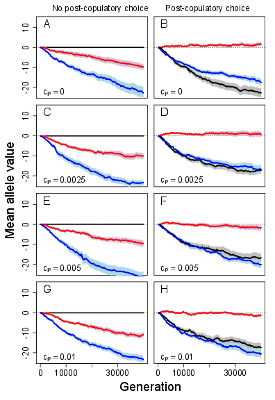

Mean allele values underlying tendency for polyandry (red), pre-copulatory inbreeding strategy (blue), and post-copulatory inbreeding strategy (black) from simulations where post-copulatory inbreeding strategy is (A, C, E, and G) fixed to zero (i.e., random fertilisation) or (B, D, F, and H) allowed to evolve freely. Costs of polyandry (c_p) increase across rows from zero (A and B) to 0.01 (G and H). Mean allele values (solid lines) and associated standard errors (shading) are calculated across all individuals within a population over 40000 generations across 40 replicate populations. Negative mean allele values indicate inbreeding avoidance or tendency for monandry, and positive values indicate inbreeding preference or tendency for polyandry. Dotted lines demarcate mean allele values of zero.

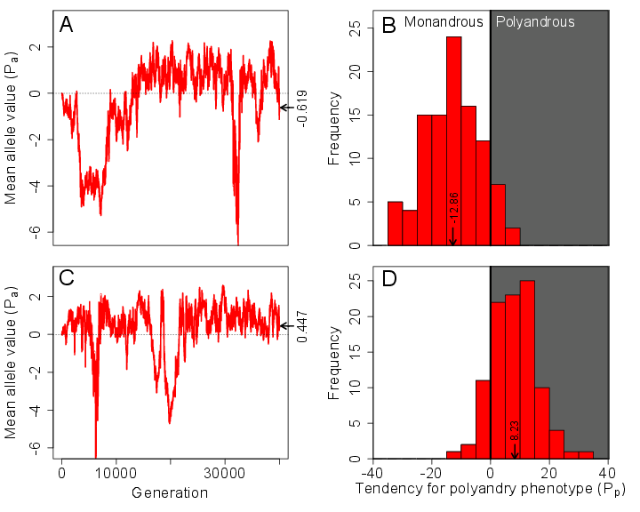

Relationships between (A and C) polyandry allele values and (B and D) monandry and polyandry phenotypes for simulations with identical initial conditions, default parameter values, and zero costs. Red lines in (A) and (C) show mean polyandry allele values across all individuals in a single simulation over 40000 generations. Positive and negative allele values contribute to polyandry and monandry, respectively. In the final generation, mean allele value was below (A) or above (C) zero (demarcated by the dotted line). Nevertheless, due to the threshold nature of expression of the polygenic polyandry phenotype, polyandry and monandry are expressed in both populations. Histograms in (B) and (D) show females’ tendency for polyandry phenotypes in the final generation; white and grey shading indicates monandrous and polyandrous females, respectively. Arrows and numbers indicate mean phenotype values. Because each trait includes 10 diploid loci with additive effects, phenotype values are ca 20 times allele values.

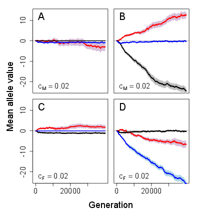

Mean allele values underlying tendency for polyandry (red), pre-copulatory inbreeding strategy (blue), and post-copulatory inbreeding strategy (black) when (A and B) costly pre-copulatory inbreeding strategy ($c_{M} = 0.02$) can evolve and post-copulatory inbreeding strategy is (A) fixed for random fertilisation or (B) can also evolve, and when (C and D) costly post-copulatory inbreeding strategy ($c_{F} = 0.02$) can evolve and pre-copulatory inbreeding strategy is (C) fixed for random mating or (D) can also evolve. Mean allele values (solid lines) and associated standard errors (shading) are calculated across all individuals within a population over 40000 generations across 40 replicate populations. Negative mean allele values indicate strategies of inbreeding avoidance or tendency for monandry, and positive values indicate strategies of inbreeding preference or tendency for polyandry. In all panels, polyandry is cost free.

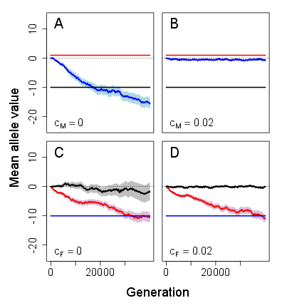

## References

Akçay, E., and J. Roughgarden. 2007. Extra-pair paternity in birds: Review of the genetic benefits. Evolutionary Ecology Research 9:855–868.

Ala-Honkola, O., M. K. Manier, S. Lüpold, and S. Pitnick. 2011. No evidence for postcopulatory inbreeding avoidance in Drosophila melanogaster. Evolution 65:2699–2705.

Arct, A., S. M. Drobniak, and M. Cicho. 2015. Genetic similarity between mates predicts extrapair paternity–a meta-analysis of bird studies. Behavioral Ecology 00:1–10.

Arnqvist, G., and L. Rowe. 2005. Sexual Conflict. Princeton University Press, Princeton, New Jersey.

Atamas, S. P., and J. Bell. 2009. Degeneracy-driven self-structuring dynamics in selective repertoires. Bulletin of Mathematical Biology 71:1349–1365.

Bateson, P. 1983. Optimal outbreeding. Pp. 257–277 *in* Mate choice. University Press, Cambridge, Cambridge.

Bocedi, G., and J. M. Reid. 2014. Evolution of female multiple mating: a quantitative model of the “sexually-selected sperm” hypothesis. Evolution 69:39–58.

Bretman, A., D. Newcombe, and T. Tregenza. 2009. Promiscuous females avoid inbreeding by controlling sperm storage. Molecular Ecology 18:3340–3345.

Bussiére, L. F., J. Hunt, M. D. Jennions, and R. Brooks. 2006. Sexual conflict and cryptic female choice in the black field cricket, Teleogryllus commodus. Evolution 60:792–800.

Charlesworth, B., and D. Charlesworth. 1999. The genetic basis of inbreeding depression. Genetical Research 74:329–340.

Charlesworth, D., and J. H. Willis. 2009. The genetics of inbreeding depression. Nature Reviews Genetics 10:783–796.

Daniel, M. J., and F. H. Rodd. 2015. Female guppies can recognize kin but only avoid incest when previously mated. Behavioral Ecology 27:55–61.

Dougherty, L. R., L. W. Simmons, and D. M. Shuker. 2016. Postcopulatory sexual selection when a female mates once. Animal Behaviour 116:13–16. Elsevier Ltd.

Duthie, A. B., and J. M. Reid. 2016. Evolution of inbreeding avoidance and inbreeding preference through mate choice among interacting relatives. American Naturalist 188:000–000.

Duthie, A. B., and J. M. Reid. 2015. What happens after inbreeding avoidance? Inbreeding by rejected relatives and the inclusive fitness benefit of inbreeding avoidance. PLoS One 10:e0125140.

Duthie, A. B., G. Bocedi, and J. M. Reid. 2016. When does female multiple mating evolve to adjust inbreeding? Effects of inbreeding depression, direct costs, mating constraints, and polyandry as a threshold trait. Evolution 70:1927–1943.

Edelman, G. M., and J. A. Gally. 2001. Degeneracy and complexity in biological systems. Proceedings of the National Academy of Sciences 98:13763–13768.

Firman, R. C., and L. W. Simmons. 2015. Gametic interactions promote inbreeding avoidance in house mice. Ecology Letters, doi: 10.1111/j.1558-5646.2007.00307.x.

Firman, R. C., and L. W. Simmons. 2008. Polyandry facilitates postcopulatory inbreeding avoidance in house mice. Evolution 62:603–611.

Fischer, K., I. Karl, S. Heuskin, S. Janowitz, and S. Dötterl. 2015. Kin recognition and inbreeding avoidance in a butterfly. Ethology 121:977–984.

Fitzpatrick, J. L., and J. P. Evans. 2014. Postcopulatory inbreeding avoidance in guppies. Journal of Evolutionary Biology 27:2585–2594.

Foerster, K., K. Delhey, A. Johnsen, J. T. Lifjeld, and B. Kempenaers. 2003. Females increase offspring heterozygosity and fitness through extra-pair matings. Nature 425:714–717.

Gardner, A., and A. T. Kalinka. 2006. Recombination and the evolution of mutational robustness. Journal of Theoretical Biology 241:707–715.

Gasparini, C., and A. Pilastro. 2011. Cryptic female preference for genetically unrelated males is mediated by ovarian fluid in the guppy. Proceedings. Biological sciences / The Royal Society 278:2495–2501.

Greeff, J. M., G. J. J. V. Vuuren, P. Kryger, and J. C. Moore. 2009. Outbreeding and possibly inbreeding depression in a pollinating fig wasp with a mixed mating system. Heredity 102:349–356.

Guillaume, F., and N. Perrin. 2009. Inbreeding load, bet hedging, and the evolution of sex-biased dispersal. American Naturalist 173:536–541.

Jennions, M. D., and M. Petrie. 2000. Why do females mate multiply? A review of the genetic benefits. Biological reviews of the Cambridge Philosophical Society 75:21–64.

Keller, L. F., and D. M. Waller. 2002. Inbreeding effects in wild populations. Trends in Ecology & Evolution 17:19–23.

Kimura, M. 1965. A stochastic model concerning the maintenance of genetic variability in quantitative characters. Proceedings of the National Academy of Sciences 54:731–736.

Kingma, S. A., M. L. Hall, and A. Peters. 2013. Breeding synchronization facilitates extrapair mating for inbreeding avoidance. Behavioral Ecology 24:1390–1397.

Koga, T., P. R. Y. Backwell, M. D. Jennions, and J. H. Christy. 1998. Elevated predation risk changes mating behaviour and courtship in a fiddler crab. Proceedings of the Royal Society B: Biological Sciences 265:1385–1390.

Kokko, H., and J. Mappes. 2013. Multiple mating by females is a natural outcome of a null model of mate encounters. Entomologia Experimentalis et Applicata 146:26–37.

Kokko, H., and I. Ots. 2006. When not to avoid inbreeding. Evolution 60:467–475.

Kokko, H., R. Brooks, M. D. Jennions, and J. Morley. 2003. The evolution of mate choice and mating biases. Proceedings of The Royal Society B 270:653–664.

Kuriwada, T., N. Kumano, K. Shiromoto, and D. Haraguchi. 2011. Inbreeding avoidance or tolerance? Comparison of mating behavior between mass-reared and wild strains of the sweet potato weevil. Behavioral Ecology and Sociobiology 65:1483–1489.

Lande, R. 1976. The maintenance of genetic variability by mutation in a polygenic character with linked loci. Genetical Research 36:221–235.

Lehtonen, J., and H. Kokko. 2015. Why inclusive fitness can make it adaptive to produce less fit extra-pair offspring. Proceedings of the Royal Society B 282:20142716.

Levin, S. A., and J. Lubchenco. 2008. Resilience, robustness, and marine ecosystem-based management. 58:27–32.

Lihoreau, M., C. Zimmer, and C. Rivault. 2007. Kin recognition and incest avoidance in a group-living insect. Behavioral Ecology 18:880–887.

Liu, X., X. Tu, H. He, C. Chen, and F. Xue. 2014. Evidence for inbreeding depression and pre-copulatory, but not post copulatory inbreeding avoidance in the cabbage beetle Colaphellus bowringi. PloS one 9:e94389.

Lynch, M., and B. Walsh. 1998. Genetics and Analysis of Quantitative Traits. Sinauer, Sunderland.

Metzger, M., C. Bernstein, T. S. Hoffmeister, and E. Desouhant. 2010a. Does kin recognition and sib-mating avoidance limit the risk of genetic incompatibility in a parasitic wasp? PLoS One 5:1–6.

Metzger, M., D. Fischbein, A. Auguste, X. Fauvergue, C. Bernstein, and E. Desouhant. 2010b. Synergy in information use for mate finding: Demonstration in a parasitoid wasp. Animal Behaviour 79:1307–1315. Elsevier Ltd.

Mills, L. S., and P. E. Smouse. 1994. Demographic consequences of inbreeding in remnant populations. American Naturalist 144:412–431.

Morton, N. E., J. F. Crow, and H. J. Muller. 1956. An estimate of the mutational damage in man from data on consanguineous marriages. Proceedings of the National Academy of Sciences 42:855–863.

Nowak, M. A., M. C. Boerlijst, J. Cooke, and J. Maynard Smith. 1997. Evolution of genetic redundancy. Nature 388:167–171.

Park, H. J., and K. J. Friston. 2013. Structural and functional brain networks: from connections to cognition. Science 342:1238411.

Parker, G. A. 2006. Sexual conflict over mating and fertilization: an overview. Philosophical Transactions of the Royal Society B 361:235–259.

Parker, G. A. 1979. Sexual selection and sexual conflict. Pp. 123–166 *in* M. S. Blum and N. A. Blum, eds. Sexual selection and reproductive competition in insects. Academic Press, Inc, New York.

Pizzari, T., H. Løvlie, and C. K. Cornwallis. 2004. Sex-specific, counteracting responses to inbreeding in a bird. Proceedings of The Royal Society B 271:2115–2121.

Pomiankowski, A. 1987. The costs of choice in sexual selection. Journal of Theoretical Biology 128:195–218.

Potts, W. K., C. J. Manning, and E. K. Wakeland. 1991. Mating patterns in seminatural populations of mice influenced by MHC genotype. Nature 352:619–621.

Price, C. J., and K. J. Friston. 2002. Degeneracy and cognitive anatomy. Trends in Cognitive Sciences 6:416–421.

Pusey, A., and M. Wolf. 1996. Inbreeding avoidance in animals. Trends in Ecology & Evolution 5347:298–301.

Reeve, J. P. 2000. Predicting long-term response to selection. Genetical Research 75:83–94.

Reid, J. M. 2015. What can we really say about relatedness and extrapair paternity: a comment on Arct et al. Behavioral Ecology 00:1–2.

Reid, J. M., P. Arcese, L. F. Keller, R. R. Germain, A. B. Duthie, S. Losdat, M. E. Wolak, and P. Nietlisbach. 2015a. Quantifying inbreeding avoidance through extra-pair reproduction. Evolution 69:59–74.

Reid, J. M., A. B. Duthie, M. E. Wolak, and P. Arcese. 2015b. Demographic mechanisms of inbreeding adjustment through extra-pair reproduction. Journal of Animal Ecology 84:1029–1040.

Roberts, K. E., S. E. F. Evison, B. Baer, and W. O. H. Hughes. 2015. The cost of promiscuity: sexual transmission of Nosema microsporidian parasites in polyandrous honey bees. Scientific Reports 5:10982. Nature Publishing Group.

Roff, D. A. 1998. Evolution of threshold traits: the balance between directional selection, drift and mutation. Heredity 80:25–32.

Roff, D. A. 1996. The evolution of threshold traits in animals. The Quarterly Review of Biology 71:3–35.

Ronkainen, H., and H. Ylonen. 1994. Behaviour of cyclic bank voles under risk of mustelid predation: Do females avoid copulations? Oecologia 97:377–381.

Rowe, L. 1988. Cost of mating for female insects: risk of predation in Photinus collustrans (Coleoptera: Lampyridae). American Naturalist 121:139–142.

Rowe, L., G. Arnqvist, A. Sih, and J. J. Krupa. 1994. Sexual conflict and the evolutionary ecology of mating patterns: water striders as a model system. Trends in Ecology & Evolution 9:289–293.

Simmons, L. W., M. Beveridge, N. Wedell, and T. Tregenza. 2006. Postcopulatory inbreeding avoidance by female crickets only revealed by molecular markers. Molecular Ecology 15:3817–3824.

Suraci, J. P., M. Clinchy, and L. Y. Zanette. 2017. Do large carnivores and mesocarnivores have redundant impacts on intertidal prey? PLoS One 12:e0170255.

Szulkin, M., K. V. Stopher, J. M. Pemberton, and J. M. Reid. 2013. Inbreeding avoidance, tolerance, or preference in animals? Trends in Ecology & Evolution 28:205–211. Elsevier Ltd.

Tan, C. K. W., H. Løvlie, T. Pizzari, and S. Wigby. 2012. No evidence for precopulatory inbreeding avoidance in Drosophila melanogaster. Animal Behaviour 83:1433–1441. Elsevier Ltd.

Tregenza, T., and N. Wedell. 2002. Polyandrous females avoid costs of inbreeding. Nature 415:71–73.

Tuni, C., M. Beveridge, and L. W. Simmons. 2013. Female crickets assess relatedness during mate guarding and bias storage of sperm towards unrelated males. Journal of Evolutionary Biology 26:1261–1268.

Varian-Ramos, C. W., and M. S. Webster. 2012. Extrapair copulations reduce inbreeding for female red-backed fairy-wrens, Malurus melanocephalus. Animal Behaviour 83:857–864. Elsevier Ltd.

Whitacre, J. M. 2010. Degeneracy: a link between evolvability, robustness and complexity in biological systems. Theoretical Biology and Medical Modelling 7:6.

Whitacre, J., and A. Bender. 2010. Degeneracy: A design principle for achieving robustness and evolvability. Journal of Theoretical Biology 263:143–153. Elsevier.

Zeh, J. A., and D. W. Zeh. 1997. The evolution of polyandry II: post-copulatory defenses against genetic incompatibility. Proceedings of the Royal Society B 264:69–75.